# Mi Primer R NoteBook

# Texto

## Italicas y Negritas

- La palabra **hola** esta en negritas.
  - Utilizamos `**hola**`
- La palabra *mundo* esta en italicas.
  - Utilizamos `*mundo*`

## Sub y Supra indice

- La formula quimica del agua es H<sub>2</sub>0 y la del carbonato de sodio es Na<sub>2</sub>CO<sub>3</sub>
  - `H~2~0` = H<sub>2</sub>0
  - `Na~2~CO~3~` = Na<sub>2</sub>CO<sub>3</sub>
- Tambien podemos incluir texto
  - Precio<sub>dia</sub> = `Precio~dia~`
  - No puede incluir espacio
- Tambien podemos hacer exponentes X<sup>2</sup>
  - x<sup>2</sup> = `x^2^`

## inline Code

Codigo `x <- x+1`

## Hiperlinks

- Para crear un link usamos `[Text](Link)`
  - Ejmeplo: [Academatica](https://www.youtube.com/academatica)

# imagenes

Para agregar imagenes usamos `![Text](path a imagen)`

# Referencias

Para agregar pie de pagina utilizamos `^[]`

Para este demo usaremos como referencia el libro *R Markdown: The Definitive Guide*[^1]

# Encabezados y Sub Encabezados

- `#` Heading 1
- `##` Heading 2
- `###` Heading 3

# listas

## listas no ordenadas

Podemos usar `-`, `+` o `*`

```
+ item 1
  + item 1.1
  + item 1.2
+ item 2
```

- item 1
  - item 1.1
  - item 1.2
- item 2

## Listas Ordenadas

```
1. Item 1
   * item 1.1
2. Item 2
   1. item 2.1
   2. item 2.2
```

1. Item 1
   - item 1.1
2. Item 2
   1. item 2.1
   2. item 2.2

# Quotes

```
> In God we trust, all others bring data.
>
> --- W Edwards Deming
```

> “In God we trust, all others bring data.”

> — W Edwards Deming

> “Keep away from people who try to belittle your ambitions. Small people always do that, but the really great make you feel that you, too, can become great.”

> — Mark Twain

# Plain Code Chunks

Despues de 3 backticks se puede escribir chunk de codigo

```
SELECT *
FROM schema.table
WHERE id > 100
ORDER BY date
LIMIT 10
```

# Expresiones matematica

`$\int_a^b e^x dx = e^x+C$` inline

$\int_a^b e^x dx = e^x+C$

`$$\int_a^b e^x dx = e^x+C$$`
$$\int_a^b e^x dx = e^x+C$$

```
$$X = \begin{bmatrix}1 & x_{1}\\
1 & x_{2}\\
1 & x_{3}
\end{bmatrix}$$
```

$$X = \begin{bmatrix}1 & x_{1}\\
1 & x_{2}\\
1 & x_{3}
\end{bmatrix}$$

```
$$\Theta = \begin{pmatrix}\alpha & \beta\\
\gamma & \delta
\end{pmatrix}$$
```

$$\Theta = \begin{pmatrix}\alpha & \beta\\
\gamma & \delta
\end{pmatrix}$$

Todas las ecuaciones se escriben usando Latex. Es de mucha utilidad este generador de latex.

[Generador de Latex](https://www.codecogs.com/latex/eqneditor.php)

# Chunks de codigo

`ctrl + alt + i`

```r
head(mtcars)
```

|  | mpg | cyl | disp | hp | drat | wt | qsec | vs | am | gear | carb |
| --- | --- | --- | --- | --- | --- | --- | --- | --- | --- | --- | --- |
| Mazda RX4 | 21.0 | 6 | 160 | 110 | 3.90 | 2.620 | 16.46 | 0 | 1 | 4 | 4 |
| Mazda RX4 Wag | 21.0 | 6 | 160 | 110 | 3.90 | 2.875 | 17.02 | 0 | 1 | 4 | 4 |
| Datsun 710 | 22.8 | 4 | 108 | 93 | 3.85 | 2.320 | 18.61 | 1 | 1 | 4 | 1 |
| Hornet 4 Drive | 21.4 | 6 | 258 | 110 | 3.08 | 3.215 | 19.44 | 1 | 0 | 3 | 1 |
| Hornet Sportabout | 18.7 | 8 | 360 | 175 | 3.15 | 3.440 | 17.02 | 0 | 0 | 3 | 2 |
| Valiant | 18.1 | 6 | 225 | 105 | 2.76 | 3.460 | 20.22 | 1 | 0 | 3 | 1 |

Las variables se mantienen entre chunks.

```r
x <- sample(letters,replace=TRUE,size=10)
```

```r
print(x)
```

```
 [1] "f" "h" "a" "w" "c" "l" "r" "u" "r" "g"
```

```r
num<- 1+3
```

La variable num contiene el valor de 4`

## Graficas

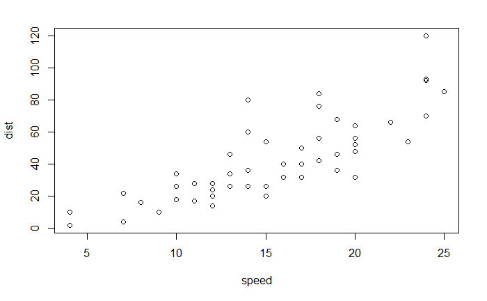

# Python

Usa la libreria [reticulate](https://rstudio.github.io/reticulate/)

```r
library(reticulate)
```

```python
reticulate::repl_python()
```

```
Python 3.6.13 (C:/Users/hdtah/AppData/Local/r-miniconda/envs/r-reticulate/python.exe)
Reticulate 1.22 REPL -- A Python interpreter in R.
Enter 'exit' or 'quit' to exit the REPL and return to R.
```

```python
x = 42 * 2
print(x)
```

```
84
```

Instalando librerias de python `py_install("pandas")`

Instalando una libreria a un ambiente de conda `conda_install("r-reticulate", "pandas")`

```r
quit
#conda_install("r-reticulate", "pandas")

use_condaenv("r-reticulate")
```

```python
reticulate::repl_python()
```

```
Python 3.6.13 (C:/Users/hdtah/AppData/Local/r-miniconda/envs/r-reticulate/python.exe)
Reticulate 1.22 REPL -- A Python interpreter in R.
Enter 'exit' or 'quit' to exit the REPL and return to R.
```

```python
import pandas

iris_pandas = pandas.read_csv("iris.txt")
iris_setosa = iris_pandas[iris_pandas['species'] == "setosa"]
iris_setosa.head()
```

```
   sepal_length  sepal_width  petal_length  petal_width species
0           5.1          3.5           1.4          0.2  setosa
1           4.9          3.0           1.4          0.2  setosa
2           4.7          3.2           1.3          0.2  setosa
3           4.6          3.1           1.5          0.2  setosa
4           5.0          3.6           1.4          0.2  setosa
```

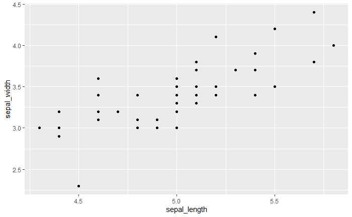

```r
quit
library(ggplot2)
library(dplyr)
py$iris_setosa %>%
  ggplot(aes(x=sepal_length,y=sepal_width))+
  geom_point()
```

# SQL

```r
library(RMySQL)
dbcon <- dbConnect(MySQL(),
                   host = '127.0.0.1',
                   user = 'root',
                   password = 'D5ekyngy',
                   dbname = 'agroserviciodb')
```

```sql
SELECT *
FROM clientes
limit 10
```

| id | id_tipo_cliente | nit_cliente | estado_cliente | created_at | updated_at |
| --- | --- | --- | --- | --- | --- |
| 6 | 1 | C/F | 1 | 2021-02-08 13:45:31 | 2021-02-08 13:45:31 |
| 7 | 3 | C/F | 1 | 2021-02-08 15:10:22 | 2021-02-08 15:10:22 |
| 9 | 3 | C/F | 1 | 2021-02-28 04:01:20 | 2021-02-28 04:01:20 |
| 10 | 2 | C/F | 1 | 2021-03-10 06:13:13 | 2021-03-10 06:13:13 |
| 11 | 3 | C/F | 1 | 2021-03-12 01:08:38 | 2021-03-12 01:08:38 |
| 12 | 3 | C/F | 1 | 2021-03-12 09:07:40 | 2021-03-12 09:07:40 |
| 13 | 3 | C/F | 1 | 2021-03-12 09:07:41 | 2021-03-12 09:07:41 |
| 14 | 3 | C/F | 1 | 2021-03-12 09:07:42 | 2021-03-12 09:07:42 |
| 15 | 3 | C/F | 1 | 2021-03-12 09:07:42 | 2021-03-12 09:07:42 |
| 16 | 3 | C/F | 1 | 2021-03-12 09:07:42 | 2021-03-12 09:07:42 |

```r
dbDisconnect(dbcon)
```

```
[1] TRUE
```